# Travel_Package_Purchase_Prediction_Final

## Travel Package Purchase Prediction

## Exploratory Data Analysis on the data

## Insights on Data Pre Processing

## Insights of model buildingbagging

## Model performance improvement - Bagging

## Insights of model performance bagging

## Model building - Boosting

## Insights of model building Boosting

## Model performance improvement - Boosting

## Insights of model performance improvement - Boosting

## Model performance evaluation

## Insights of model performanace evaluation

## Actionable Insights & Recommendations

```python
import pandas as pd
import numpy as np
from sklearn import metrics
import matplotlib.pyplot as plt
%matplotlib inline
import warnings
warnings.filterwarnings('ignore')
import seaborn as sns
from sklearn.model_selection import train_test_split
from sklearn.model_selection import GridSearchCV
from sklearn import metrics
from sklearn.impute import SimpleImputer
from sklearn.ensemble import BaggingClassifier, RandomForestClassifier
from sklearn.linear_model import LogisticRegression
from sklearn.ensemble import AdaBoostClassifier, GradientBoostingClassifier
#To install xgboost library use - !pip install xgboost
from xgboost import XGBClassifier
from sklearn.tree import DecisionTreeClassifier


from IPython.core.display import display, HTML
display(HTML("<style>.container { width:100% !important; }</style>"))


# important CV search avoiding when rerun
no_grid_search = True # To avoid time taking search used when we rerun same.
```

```python
from google.colab import drive
drive.mount('/content/drive')
```

```python
tourDF= pd.read_excel('/content/drive/MyDrive/Tourism.xlsx','Tourism')
```

## **Basic operation**

1. Shape, describe, info - to understand features
2. Finding Duplicates - if any
3. Look for mis spelled or duplicate values in column.

```python
tourDF.head(10)
```

|  | CustomerID | ProdTaken | Age | TypeofContact | CityTier | DurationOfPitch | Occupation | Gender | NumberOfPersonVisited | NumberOfFollowups | ProductPitched | PreferredPropertyStar | MaritalStatus | NumberOfTrips | Passport | PitchSatisfactionScore | OwnCar | NumberOfChildrenVisited | Designation | MonthlyIncome |
| --- | --- | --- | --- | --- | --- | --- | --- | --- | --- | --- | --- | --- | --- | --- | --- | --- | --- | --- | --- | --- |
| 0 | 200000 | 1 | 41.0 | Self Enquiry | 3 | 6.0 | Salaried | Female | 3 | 3.0 | Deluxe | 3.0 | Single | 1.0 | 1 | 2 | 1 | 0.0 | Manager | 20993.0 |
| 1 | 200001 | 0 | 49.0 | Company Invited | 1 | 14.0 | Salaried | Male | 3 | 4.0 | Deluxe | 4.0 | Divorced | 2.0 | 0 | 3 | 1 | 2.0 | Manager | 20130.0 |
| 2 | 200002 | 1 | 37.0 | Self Enquiry | 1 | 8.0 | Free Lancer | Male | 3 | 4.0 | Basic | 3.0 | Single | 7.0 | 1 | 3 | 0 | 0.0 | Executive | 17090.0 |
| 3 | 200003 | 0 | 33.0 | Company Invited | 1 | 9.0 | Salaried | Female | 2 | 3.0 | Basic | 3.0 | Divorced | 2.0 | 1 | 5 | 1 | 1.0 | Executive | 17909.0 |
| 4 | 200004 | 0 | NaN | Self Enquiry | 1 | 8.0 | Small Business | Male | 2 | 3.0 | Basic | 4.0 | Divorced | 1.0 | 0 | 5 | 1 | 0.0 | Executive | 18468.0 |
| 5 | 200005 | 0 | 32.0 | Company Invited | 1 | 8.0 | Salaried | Male | 3 | 3.0 | Basic | 3.0 | Single | 1.0 | 0 | 5 | 1 | 1.0 | Executive | 18068.0 |
| 6 | 200006 | 0 | 59.0 | Self Enquiry | 1 | 9.0 | Small Business | Female | 2 | 2.0 | Basic | 5.0 | Divorced | 5.0 | 1 | 2 | 1 | 1.0 | Executive | 17670.0 |
| 7 | 200007 | 0 | 30.0 | Self Enquiry | 1 | 30.0 | Salaried | Male | 3 | 3.0 | Basic | 3.0 | Married | 2.0 | 0 | 2 | 0 | 1.0 | Executive | 17693.0 |
| 8 | 200008 | 0 | 38.0 | Company Invited | 1 | 29.0 | Salaried | Male | 2 | 4.0 | Standard | 3.0 | Unmarried | 1.0 | 0 | 3 | 0 | 0.0 | Senior Manager | 24526.0 |
| 9 | 200009 | 0 | 36.0 | Self Enquiry | 1 | 33.0 | Small Business | Male | 3 | 3.0 | Deluxe | 3.0 | Divorced | 7.0 | 0 | 3 | 1 | 0.0 | Manager | 20237.0 |

## **Data Pre Processing**

```python
tourDF.info()
```

```
<class 'pandas.core.frame.DataFrame'>
RangeIndex: 4888 entries, 0 to 4887
Data columns (total 20 columns):
 #   Column                   Non-Null Count  Dtype
---  ------                   --------------  -----
 0   CustomerID               4888 non-null   int64
 1   ProdTaken                4888 non-null   int64
 2   Age                      4662 non-null   float64
 3   TypeofContact            4863 non-null   object
 4   CityTier                 4888 non-null   int64
 5   DurationOfPitch          4637 non-null   float64
 6   Occupation               4888 non-null   object
 7   Gender                   4888 non-null   object
 8   NumberOfPersonVisited    4888 non-null   int64
 9   NumberOfFollowups        4843 non-null   float64
 10  ProductPitched           4888 non-null   object
 11  PreferredPropertyStar    4862 non-null   float64
 12  MaritalStatus            4888 non-null   object
 13  NumberOfTrips            4748 non-null   float64
 14  Passport                 4888 non-null   int64
 15  PitchSatisfactionScore   4888 non-null   int64
 16  OwnCar                   4888 non-null   int64
 17  NumberOfChildrenVisited  4822 non-null   float64
 18  Designation              4888 non-null   object
 19  MonthlyIncome            4655 non-null   float64
dtypes: float64(7), int64(7), object(6)
memory usage: 763.9+ KB
```

```python
tourDF.shape
```

```
(4888, 20)
```

### **Insights**

1. There are 4888 rows in the dataset.
2. Missing Values - Age, Type of contact, Duration Pitch, Number of Followups, Prederred property start,number of trips, Number of Childeren visited and Montly Income
3. There are 20 columns

```python
tourDF.describe().T
```

|  | count | mean | std | min | 25% | 50% | 75% | max |
| --- | --- | --- | --- | --- | --- | --- | --- | --- |
| CustomerID | 4888.0 | 202443.500000 | 1411.188388 | 200000.0 | 201221.75 | 202443.5 | 203665.25 | 204887.0 |
| ProdTaken | 4888.0 | 0.188216 | 0.390925 | 0.0 | 0.00 | 0.0 | 0.00 | 1.0 |
| Age | 4662.0 | 37.622265 | 9.316387 | 18.0 | 31.00 | 36.0 | 44.00 | 61.0 |
| CityTier | 4888.0 | 1.654255 | 0.916583 | 1.0 | 1.00 | 1.0 | 3.00 | 3.0 |
| DurationOfPitch | 4637.0 | 15.490835 | 8.519643 | 5.0 | 9.00 | 13.0 | 20.00 | 127.0 |
| NumberOfPersonVisited | 4888.0 | 2.905074 | 0.724891 | 1.0 | 2.00 | 3.0 | 3.00 | 5.0 |
| NumberOfFollowups | 4843.0 | 3.708445 | 1.002509 | 1.0 | 3.00 | 4.0 | 4.00 | 6.0 |
| PreferredPropertyStar | 4862.0 | 3.581037 | 0.798009 | 3.0 | 3.00 | 3.0 | 4.00 | 5.0 |
| NumberOfTrips | 4748.0 | 3.236521 | 1.849019 | 1.0 | 2.00 | 3.0 | 4.00 | 22.0 |
| Passport | 4888.0 | 0.290917 | 0.454232 | 0.0 | 0.00 | 0.0 | 1.00 | 1.0 |
| PitchSatisfactionScore | 4888.0 | 3.078151 | 1.365792 | 1.0 | 2.00 | 3.0 | 4.00 | 5.0 |
| OwnCar | 4888.0 | 0.620295 | 0.485363 | 0.0 | 0.00 | 1.0 | 1.00 | 1.0 |
| NumberOfChildrenVisited | 4822.0 | 1.187267 | 0.857861 | 0.0 | 1.00 | 1.0 | 2.00 | 3.0 |
| MonthlyIncome | 4655.0 | 23619.853491 | 5380.698361 | 1000.0 | 20346.00 | 22347.0 | 25571.00 | 98678.0 |

```python
tourDF['CustomerID'].nunique()
```

```
4888
```

```python
tourDF.nunique()
```

```
CustomerID                 4888
ProdTaken                     2
Age                          44
TypeofContact                 2
CityTier                      3
DurationOfPitch              34
Occupation                    4
Gender                        3
NumberOfPersonVisited         5
NumberOfFollowups             6
ProductPitched                5
PreferredPropertyStar         3
MaritalStatus                 4
NumberOfTrips                12
Passport                      2
PitchSatisfactionScore        5
OwnCar                        2
NumberOfChildrenVisited       4
Designation                   5
MonthlyIncome              2475
dtype: int64
```

```python
def product_taken_percentage(dataframe):
  taken_series =dataframe['ProdTaken'].value_counts(dropna=False)
  print(taken_series)
  taken = taken_series[1]
  not_taken = taken_series[0]
  print(taken)
  print(not_taken)
  taken_per = taken /(taken+not_taken) * 100
  print("Percentange of product taken in dataset%s" %taken_per)


product_taken_percentage(tourDF)
```

```
0    3968
1     920
Name: ProdTaken, dtype: int64
920
3968
Percentange of product taken in dataset18.821603927986907
```

## **Insights on Data**

1. 18% of product taken in complete dataset
2. Gender has three values. - Need an analysis
3. Martial Status has four values - Need to check it.
4. ProdTaken, Type of contact, CityTier, Passport, OwnCar - looks to be have unique value

```python
columns  = tourDF.columns
columns
```

```
Index(['CustomerID', 'ProdTaken', 'Age', 'TypeofContact', 'CityTier',
       'DurationOfPitch', 'Occupation', 'Gender', 'NumberOfPersonVisited',
       'NumberOfFollowups', 'ProductPitched', 'PreferredPropertyStar',
       'MaritalStatus', 'NumberOfTrips', 'Passport', 'PitchSatisfactionScore',
       'OwnCar', 'NumberOfChildrenVisited', 'Designation', 'MonthlyIncome'],
      dtype='object')
```

```python
tourDF['Gender'].unique()
```

```
array(['Female', 'Male', 'Fe Male'], dtype=object)
```

```python
gender_typo_correct_dict={'Fe Male': 'Female'}
tourDF['Gender'].replace(gender_typo_correct_dict,inplace = True)
tourDF['Gender'].unique()
```

```
array(['Female', 'Male'], dtype=object)
```

## **Insights on Data Pre Processing**

## **Insights**

- Gender has typos for 'Fe Male'
- Replacing with 'Female'

```python
tourDF['Designation'].unique()
```

```
array(['Manager', 'Executive', 'Senior Manager', 'AVP', 'VP'],
      dtype=object)
```

```python
tourDF['Age'].unique()
```

```
array([41., 49., 37., 33., nan, 32., 59., 30., 38., 36., 35., 31., 34.,
       28., 29., 22., 53., 21., 42., 44., 46., 39., 24., 43., 50., 27.,
       26., 48., 55., 45., 56., 23., 51., 40., 54., 58., 20., 25., 19.,
       57., 52., 47., 18., 60., 61.])
```

# **Insight**

- Treating for missing value 'Age','NumberOfFollowups','DurationOfPitch','PreferredPropertyStar'
- Strategy - using most frequent (mode) for above columns

```python
missing_value_median = ['Age','NumberOfFollowups','DurationOfPitch','PreferredPropertyStar']

for feature in missing_value_median:
    print("Feature : %s has unique :%s"%(feature,tourDF[feature].unique()))
    tourDF[feature]=tourDF[feature].fillna(0)
    age_fill = SimpleImputer(missing_values=0, strategy="most_frequent")
    cols=[feature]
    imputer = age_fill.fit(tourDF[cols])
    tourDF[cols] = imputer.transform(tourDF[cols])
tourDF.info()
```

```
Feature : Age has unique :[41. 49. 37. 33. nan 32. 59. 30. 38. 36. 35. 31. 34. 28. 29. 22. 53. 21.
 42. 44. 46. 39. 24. 43. 50. 27. 26. 48. 55. 45. 56. 23. 51. 40. 54. 58.
 20. 25. 19. 57. 52. 47. 18. 60. 61.]
Feature : NumberOfFollowups has unique :[ 3.  4.  2.  5. nan  1.  6.]
Feature : DurationOfPitch has unique :[  6.  14.   8.   9.  30.  29.  33.  22.  21.  32.  25.  27.  11.  17.
  15.  13.  12.  16.  10.  31.  18.  nan  24.  35.  28.  20.  26.  34.
  23.   5.  19. 126.   7.  36. 127.]
Feature : PreferredPropertyStar has unique :[ 3.  4.  5. nan]
<class 'pandas.core.frame.DataFrame'>
RangeIndex: 4888 entries, 0 to 4887
Data columns (total 20 columns):
 #   Column                   Non-Null Count  Dtype
---  ------                   --------------  -----
 0   CustomerID               4888 non-null   int64
 1   ProdTaken                4888 non-null   int64
 2   Age                      4888 non-null   float64
 3   TypeofContact            4863 non-null   object
 4   CityTier                 4888 non-null   int64
 5   DurationOfPitch          4888 non-null   float64
 6   Occupation               4888 non-null   object
 7   Gender                   4888 non-null   object
 8   NumberOfPersonVisited    4888 non-null   int64
 9   NumberOfFollowups        4888 non-null   float64
 10  ProductPitched           4888 non-null   object
 11  PreferredPropertyStar    4888 non-null   float64
 12  MaritalStatus            4888 non-null   object
 13  NumberOfTrips            4748 non-null   float64
 14  Passport                 4888 non-null   int64
 15  PitchSatisfactionScore   4888 non-null   int64
 16  OwnCar                   4888 non-null   int64
 17  NumberOfChildrenVisited  4822 non-null   float64
 18  Designation              4888 non-null   object
 19  MonthlyIncome            4655 non-null   float64
dtypes: float64(7), int64(7), object(6)
memory usage: 763.9+ KB
```

## **Insights on Data Pre Processing**

**Insights**

- Treating - 'NumberOfTrips','NumberOfChildrenVisited'
- Assuming missing value for these columns to be 0.

```python
missing_columns_replace_zero = ['NumberOfTrips','NumberOfChildrenVisited']

for feature in missing_columns_replace_zero:
    tourDF[feature]=tourDF[feature].fillna(0)

tourDF.info()
```

```
<class 'pandas.core.frame.DataFrame'>
RangeIndex: 4888 entries, 0 to 4887
Data columns (total 20 columns):
 #   Column                   Non-Null Count  Dtype
---  ------                   --------------  -----
 0   CustomerID               4888 non-null   int64
 1   ProdTaken                4888 non-null   int64
 2   Age                      4888 non-null   float64
 3   TypeofContact            4863 non-null   object
 4   CityTier                 4888 non-null   int64
 5   DurationOfPitch          4888 non-null   float64
 6   Occupation               4888 non-null   object
 7   Gender                   4888 non-null   object
 8   NumberOfPersonVisited    4888 non-null   int64
 9   NumberOfFollowups        4888 non-null   float64
 10  ProductPitched           4888 non-null   object
 11  PreferredPropertyStar    4888 non-null   float64
 12  MaritalStatus            4888 non-null   object
 13  NumberOfTrips            4888 non-null   float64
 14  Passport                 4888 non-null   int64
 15  PitchSatisfactionScore   4888 non-null   int64
 16  OwnCar                   4888 non-null   int64
 17  NumberOfChildrenVisited  4888 non-null   float64
 18  Designation              4888 non-null   object
 19  MonthlyIncome            4655 non-null   float64
dtypes: float64(7), int64(7), object(6)
memory usage: 763.9+ KB
```

## **Insights on Data Pre Processing**

### **Missing Value Treatment**

- Treating - 'Montly Income'
- Based on Designation mean - filling those values

```python
AverageIncomeByDesignation = tourDF.groupby(['Designation'])['MonthlyIncome'].mean()

print(AverageIncomeByDesignation)

missing_column_replace_based_on_desgination = ['MonthlyIncome']

for feature in missing_column_replace_based_on_desgination:
    # print("Feature : %s has unique :%s"%(feature,tourDF[feature].unique()))
    tourDF[feature].fillna(tourDF['Designation'].apply(lambda x: AverageIncomeByDesignation[x]),inplace=True)
    # tourDF[feature] = tourDF['Designation'].apply(lambda x: AverageIncomeByDesignation[x])

tourDF.info()
```

```
Designation
AVP               32241.046784
Executive         19939.922507
Manager           22643.157629
Senior Manager    26637.749326
VP                35878.947826
Name: MonthlyIncome, dtype: float64
<class 'pandas.core.frame.DataFrame'>
RangeIndex: 4888 entries, 0 to 4887
Data columns (total 20 columns):
 #   Column                   Non-Null Count  Dtype
---  ------                   --------------  -----
 0   CustomerID               4888 non-null   int64
 1   ProdTaken                4888 non-null   int64
 2   Age                      4888 non-null   float64
 3   TypeofContact            4863 non-null   object
 4   CityTier                 4888 non-null   int64
 5   DurationOfPitch          4888 non-null   float64
 6   Occupation               4888 non-null   object
 7   Gender                   4888 non-null   object
 8   NumberOfPersonVisited    4888 non-null   int64
 9   NumberOfFollowups        4888 non-null   float64
 10  ProductPitched           4888 non-null   object
 11  PreferredPropertyStar    4888 non-null   float64
 12  MaritalStatus            4888 non-null   object
 13  NumberOfTrips            4888 non-null   float64
 14  Passport                 4888 non-null   int64
 15  PitchSatisfactionScore   4888 non-null   int64
 16  OwnCar                   4888 non-null   int64
 17  NumberOfChildrenVisited  4888 non-null   float64
 18  Designation              4888 non-null   object
 19  MonthlyIncome            4888 non-null   float64
dtypes: float64(7), int64(7), object(6)
memory usage: 763.9+ KB
```

# **Missing Value Treatment**

```python
fill_list = tourDF['TypeofContact'].unique()[:1]
print(fill_list)
tourDF[tourDF['TypeofContact'].isnull()]
tourDF['TypeofContact'].fillna(pd.Series(np.random.choice(fill_list, size=len(tourDF.index))),inplace=True)
tourDF.info()
```

```
['Self Enquiry']
<class 'pandas.core.frame.DataFrame'>
RangeIndex: 4888 entries, 0 to 4887
Data columns (total 20 columns):
 #   Column                   Non-Null Count  Dtype
---  ------                   --------------  -----
 0   CustomerID               4888 non-null   int64
 1   ProdTaken                4888 non-null   int64
 2   Age                      4888 non-null   float64
 3   TypeofContact            4888 non-null   object
 4   CityTier                 4888 non-null   int64
 5   DurationOfPitch          4888 non-null   float64
 6   Occupation               4888 non-null   object
 7   Gender                   4888 non-null   object
 8   NumberOfPersonVisited    4888 non-null   int64
 9   NumberOfFollowups        4888 non-null   float64
 10  ProductPitched           4888 non-null   object
 11  PreferredPropertyStar    4888 non-null   float64
 12  MaritalStatus            4888 non-null   object
 13  NumberOfTrips            4888 non-null   float64
 14  Passport                 4888 non-null   int64
 15  PitchSatisfactionScore   4888 non-null   int64
 16  OwnCar                   4888 non-null   int64
 17  NumberOfChildrenVisited  4888 non-null   float64
 18  Designation              4888 non-null   object
 19  MonthlyIncome            4888 non-null   float64
dtypes: float64(7), int64(7), object(6)
memory usage: 763.9+ KB
```

# **Missing Value Treatment**

- Conveting object columns to categorical.

```python
for i in list(tourDF.columns[tourDF.dtypes=='object']):   # checking value counts of all object type columns
    print(tourDF[i].value_counts(normalize=True))
    tourDF[i] = pd.Categorical(tourDF[i])
tourDF.info()
```

```
Self Enquiry       0.709697
Company Invited    0.290303
Name: TypeofContact, dtype: float64
Salaried          0.484452
Small Business    0.426350
Large Business    0.088789
Free Lancer       0.000409
Name: Occupation, dtype: float64
Male      0.596563
Female    0.403437
Name: Gender, dtype: float64
Basic           0.376841
Deluxe          0.354337
Standard        0.151800
Super Deluxe    0.069967
King            0.047054
Name: ProductPitched, dtype: float64
Married      0.478723
Divorced     0.194354
Single       0.187398
Unmarried    0.139525
Name: MaritalStatus, dtype: float64
Executive         0.376841
Manager           0.354337
Senior Manager    0.151800
AVP               0.069967
VP                0.047054
Name: Designation, dtype: float64
<class 'pandas.core.frame.DataFrame'>
RangeIndex: 4888 entries, 0 to 4887
Data columns (total 20 columns):
 #   Column                   Non-Null Count  Dtype
---  ------                   --------------  -----
 0   CustomerID               4888 non-null   int64
 1   ProdTaken                4888 non-null   int64
 2   Age                      4888 non-null   float64
 3   TypeofContact            4888 non-null   category
 4   CityTier                 4888 non-null   int64
 5   DurationOfPitch          4888 non-null   float64
 6   Occupation               4888 non-null   category
 7   Gender                   4888 non-null   category
 8   NumberOfPersonVisited    4888 non-null   int64
 9   NumberOfFollowups        4888 non-null   float64
 10  ProductPitched           4888 non-null   category
 11  PreferredPropertyStar    4888 non-null   float64
 12  MaritalStatus            4888 non-null   category
 13  NumberOfTrips            4888 non-null   float64
 14  Passport                 4888 non-null   int64
 15  PitchSatisfactionScore   4888 non-null   int64
 16  OwnCar                   4888 non-null   int64
 17  NumberOfChildrenVisited  4888 non-null   float64
 18  Designation              4888 non-null   category
 19  MonthlyIncome            4888 non-null   float64
dtypes: category(6), float64(7), int64(7)
memory usage: 564.3 KB
```

## **One Hot Encoding**

- Enabling one hot encoding for columns to convert into continuos - "TypeofContact","Occupation","Gender","ProductPitched","MaritalStatus","Designation"
- Preserving productpictched, Designation category for exploratory analysis

```python
oneHotCols=["TypeofContact","Occupation","Gender","ProductPitched","MaritalStatus","Designation"]
tourDF_beforeEncoding =tourDF
tourDF["ProductPitchedCategory"] = tourDF["ProductPitched"]
tourDF["DesignationCategory"] = tourDF["Designation"]
tourDF=pd.get_dummies(tourDF,columns=oneHotCols)
print(tourDF.columns)
```

```
Index(['CustomerID', 'ProdTaken', 'Age', 'CityTier', 'DurationOfPitch',
       'NumberOfPersonVisited', 'NumberOfFollowups', 'PreferredPropertyStar',
       'NumberOfTrips', 'Passport', 'PitchSatisfactionScore', 'OwnCar',
       'NumberOfChildrenVisited', 'MonthlyIncome', 'ProductPitchedCategory',
       'DesignationCategory', 'TypeofContact_Company Invited',
       'TypeofContact_Self Enquiry', 'Occupation_Free Lancer',
       'Occupation_Large Business', 'Occupation_Salaried',
       'Occupation_Small Business', 'Gender_Female', 'Gender_Male',
       'ProductPitched_Basic', 'ProductPitched_Deluxe', 'ProductPitched_King',
       'ProductPitched_Standard', 'ProductPitched_Super Deluxe',
       'MaritalStatus_Divorced', 'MaritalStatus_Married',
       'MaritalStatus_Single', 'MaritalStatus_Unmarried', 'Designation_AVP',
       'Designation_Executive', 'Designation_Manager',
       'Designation_Senior Manager', 'Designation_VP'],
      dtype='object')
```

```python
# Function to relation of feature with product taken with percentage
def categorize_customer(feature):
    print("Feature %s"%feature)
    grouped_df = tourDF.groupby([feature,'ProdTaken'])['ProdTaken'].count()
    print('+'*100)
    # print(grouped_df)
    # print('-'*100)
    print("printing by Percentage")
    print(grouped_df.groupby(level=0).apply(lambda x: 100 * x / float(x.sum())))
    print('+'*100)
```

## **Exploratory Data Analysis on the data**

```python
# Looking into Type of contact
features =   ['TypeofContact_Company Invited', 'TypeofContact_Self Enquiry',
       'Occupation_Free Lancer', 'Occupation_Large Business',
       'Occupation_Salaried', 'Occupation_Small Business', 'Gender_Female',
       'Gender_Male', 'ProductPitched_Basic', 'ProductPitched_Deluxe',
       'ProductPitched_King', 'ProductPitched_Standard',
       'ProductPitched_Super Deluxe', 'MaritalStatus_Divorced',
       'MaritalStatus_Married', 'MaritalStatus_Single',
       'MaritalStatus_Unmarried', 'Designation_AVP', 'Designation_Executive',
       'Designation_Manager', 'Designation_Senior Manager', 'Designation_VP']

type_of_contact = ['TypeofContact_Company Invited', 'TypeofContact_Self Enquiry']

for contact in type_of_contact:
  categorize_customer(contact)
```

```
Feature TypeofContact_Company Invited
++++++++++++++++++++++++++++++++++++++++++++++++++++++++++++++++++++++++++++++++++++++++++++++++++++
printing by Percentage
TypeofContact_Company Invited  ProdTaken
0                              0            82.415682
                               1            17.584318
1                              0            78.153629
                               1            21.846371
Name: ProdTaken, dtype: float64
++++++++++++++++++++++++++++++++++++++++++++++++++++++++++++++++++++++++++++++++++++++++++++++++++++
Feature TypeofContact_Self Enquiry
++++++++++++++++++++++++++++++++++++++++++++++++++++++++++++++++++++++++++++++++++++++++++++++++++++
printing by Percentage
TypeofContact_Self Enquiry  ProdTaken
0                           0            78.153629
                            1            21.846371
1                           0            82.415682
                            1            17.584318
Name: ProdTaken, dtype: float64
++++++++++++++++++++++++++++++++++++++++++++++++++++++++++++++++++++++++++++++++++++++++++++++++++++
```

## **Insights based on EDA**

**Insights**

1. Company contacted turnover is 310/(1109+310). = 21.8 %
2. Self Enquiry turnover is 607/(2837+607) = 17%
3. Company contacted has lead over self enquiry

```python
gender_classification = ['Gender_Female',
       'Gender_Male']
for gender in gender_classification:
  categorize_customer(gender)
```

```
Feature Gender_Female
++++++++++++++++++++++++++++++++++++++++++++++++++++++++++++++++++++++++++++++++++++++++++++++++++++
printing by Percentage
Gender_Female  ProdTaken
0              0            80.178326
               1            19.821674
1              0            82.657201
               1            17.342799
Name: ProdTaken, dtype: float64
++++++++++++++++++++++++++++++++++++++++++++++++++++++++++++++++++++++++++++++++++++++++++++++++++++
Feature Gender_Male
++++++++++++++++++++++++++++++++++++++++++++++++++++++++++++++++++++++++++++++++++++++++++++++++++++
printing by Percentage
Gender_Male  ProdTaken
0            0            82.657201
             1            17.342799
1            0            80.178326
             1            19.821674
Name: ProdTaken, dtype: float64
++++++++++++++++++++++++++++++++++++++++++++++++++++++++++++++++++++++++++++++++++++++++++++++++++++
```

## **Insights based on EDA**

**Insights**

1. Male customer turnover percentage - 20%
2. Female customer turnover percentage - 18%

```python
martial_status = ['MaritalStatus_Divorced',
       'MaritalStatus_Married', 'MaritalStatus_Single',
       'MaritalStatus_Unmarried']

for status in martial_status:
  categorize_customer(status)
```

```
Feature MaritalStatus_Divorced
++++++++++++++++++++++++++++++++++++++++++++++++++++++++++++++++++++++++++++++++++++++++++++++++++++
printing by Percentage
MaritalStatus_Divorced  ProdTaken
0                       0            79.786694
                        1            20.213306
1                       0            86.947368
                        1            13.052632
Name: ProdTaken, dtype: float64
++++++++++++++++++++++++++++++++++++++++++++++++++++++++++++++++++++++++++++++++++++++++++++++++++++
Feature MaritalStatus_Married
++++++++++++++++++++++++++++++++++++++++++++++++++++++++++++++++++++++++++++++++++++++++++++++++++++
printing by Percentage
MaritalStatus_Married  ProdTaken
0                      0            76.687598
                       1            23.312402
1                      0            86.068376
                       1            13.931624
Name: ProdTaken, dtype: float64
++++++++++++++++++++++++++++++++++++++++++++++++++++++++++++++++++++++++++++++++++++++++++++++++++++
Feature MaritalStatus_Single
++++++++++++++++++++++++++++++++++++++++++++++++++++++++++++++++++++++++++++++++++++++++++++++++++++
printing by Percentage
MaritalStatus_Single  ProdTaken
0                     0            84.491440
                      1            15.508560
1                     0            66.812227
                      1            33.187773
Name: ProdTaken, dtype: float64
++++++++++++++++++++++++++++++++++++++++++++++++++++++++++++++++++++++++++++++++++++++++++++++++++++
Feature MaritalStatus_Unmarried
++++++++++++++++++++++++++++++++++++++++++++++++++++++++++++++++++++++++++++++++++++++++++++++++++++
printing by Percentage
MaritalStatus_Unmarried  ProdTaken
0                        0            82.073229
                         1            17.926771
1                        0            75.659824
                         1            24.340176
Name: ProdTaken, dtype: float64
++++++++++++++++++++++++++++++++++++++++++++++++++++++++++++++++++++++++++++++++++++++++++++++++++++
```

## **Insights based on EDA**

**Insights**

Martial Status to product taken %

1. single -33%
2. unmarried - 24%
3. Married - 14%
4. Divorced - 13%

Single leads the product taken followed by unmarried , married and divorced

```python
designation_list = ['Designation_AVP', 'Designation_Executive',
       'Designation_Manager', 'Designation_Senior Manager', 'Designation_VP']

for designation in designation_list:
  categorize_customer(designation)
```

```
Feature Designation_AVP
++++++++++++++++++++++++++++++++++++++++++++++++++++++++++++++++++++++++++++++++++++++++++++++++++++
printing by Percentage
Designation_AVP  ProdTaken
0                0            80.202376
                 1            19.797624
1                0            94.152047
                 1             5.847953
Name: ProdTaken, dtype: float64
++++++++++++++++++++++++++++++++++++++++++++++++++++++++++++++++++++++++++++++++++++++++++++++++++++
Feature Designation_Executive
++++++++++++++++++++++++++++++++++++++++++++++++++++++++++++++++++++++++++++++++++++++++++++++++++++
printing by Percentage
Designation_Executive  ProdTaken
0                      0            87.918582
                       1            12.081418
1                      0            70.032573
                       1            29.967427
Name: ProdTaken, dtype: float64
++++++++++++++++++++++++++++++++++++++++++++++++++++++++++++++++++++++++++++++++++++++++++++++++++++
Feature Designation_Manager
++++++++++++++++++++++++++++++++++++++++++++++++++++++++++++++++++++++++++++++++++++++++++++++++++++
printing by Percentage
Designation_Manager  ProdTaken
0                    0            77.313054
                     1            22.686946
1                    0            88.221709
                     1            11.778291
Name: ProdTaken, dtype: float64
++++++++++++++++++++++++++++++++++++++++++++++++++++++++++++++++++++++++++++++++++++++++++++++++++++
Feature Designation_Senior Manager
++++++++++++++++++++++++++++++++++++++++++++++++++++++++++++++++++++++++++++++++++++++++++++++++++++
printing by Percentage
Designation_Senior Manager  ProdTaken
0                           0            80.800772
                            1            19.199228
1                           0            83.288410
                            1            16.711590
Name: ProdTaken, dtype: float64
++++++++++++++++++++++++++++++++++++++++++++++++++++++++++++++++++++++++++++++++++++++++++++++++++++
Feature Designation_VP
++++++++++++++++++++++++++++++++++++++++++++++++++++++++++++++++++++++++++++++++++++++++++++++++++++
printing by Percentage
Designation_VP  ProdTaken
0               0            80.678403
                1            19.321597
1               0            91.304348
                1             8.695652
Name: ProdTaken, dtype: float64
++++++++++++++++++++++++++++++++++++++++++++++++++++++++++++++++++++++++++++++++++++++++++++++++++++
```

## **Insights based on EDA**

**Insights by Designation**

1. Executive : 30%
2. Senior Manager: 17%
3. Manager: 12%
4. VP: 9%
5. AVP :6%

Executive lead the product taken followed by senior manager, manager, VP and AVP

```python
product_pitched = ['ProductPitched_Basic', 'ProductPitched_Deluxe',
       'ProductPitched_King', 'ProductPitched_Standard',
       'ProductPitched_Super Deluxe']

for product in product_pitched:
  categorize_customer(product)
```

```
Feature ProductPitched_Basic
++++++++++++++++++++++++++++++++++++++++++++++++++++++++++++++++++++++++++++++++++++++++++++++++++++
printing by Percentage
ProductPitched_Basic  ProdTaken
0                     0            87.918582
                      1            12.081418
1                     0            70.032573
                      1            29.967427
Name: ProdTaken, dtype: float64
++++++++++++++++++++++++++++++++++++++++++++++++++++++++++++++++++++++++++++++++++++++++++++++++++++
Feature ProductPitched_Deluxe
++++++++++++++++++++++++++++++++++++++++++++++++++++++++++++++++++++++++++++++++++++++++++++++++++++
printing by Percentage
ProductPitched_Deluxe  ProdTaken
0                      0            77.313054
                       1            22.686946
1                      0            88.221709
                       1            11.778291
Name: ProdTaken, dtype: float64
++++++++++++++++++++++++++++++++++++++++++++++++++++++++++++++++++++++++++++++++++++++++++++++++++++
Feature ProductPitched_King
++++++++++++++++++++++++++++++++++++++++++++++++++++++++++++++++++++++++++++++++++++++++++++++++++++
printing by Percentage
ProductPitched_King  ProdTaken
0                    0            80.678403
                     1            19.321597
1                    0            91.304348
                     1             8.695652
Name: ProdTaken, dtype: float64
++++++++++++++++++++++++++++++++++++++++++++++++++++++++++++++++++++++++++++++++++++++++++++++++++++
Feature ProductPitched_Standard
++++++++++++++++++++++++++++++++++++++++++++++++++++++++++++++++++++++++++++++++++++++++++++++++++++
printing by Percentage
ProductPitched_Standard  ProdTaken
0                        0            80.800772
                         1            19.199228
1                        0            83.288410
                         1            16.711590
Name: ProdTaken, dtype: float64
++++++++++++++++++++++++++++++++++++++++++++++++++++++++++++++++++++++++++++++++++++++++++++++++++++
Feature ProductPitched_Super Deluxe
++++++++++++++++++++++++++++++++++++++++++++++++++++++++++++++++++++++++++++++++++++++++++++++++++++
printing by Percentage
ProductPitched_Super Deluxe  ProdTaken
0                            0            80.202376
                             1            19.797624
1                            0            94.152047
                             1             5.847953
Name: ProdTaken, dtype: float64
++++++++++++++++++++++++++++++++++++++++++++++++++++++++++++++++++++++++++++++++++++++++++++++++++++
```

## **Insights based on EDA**

**Insights by product**

1. Basic product taken over % - 30%
2. Deluxe product taken % - 11%
3. king - 9%
4. standard - 17%
5. super deluxe - 6%

Basic looks to be dominant among product taken.

```python
occupation= ['Occupation_Free Lancer', 'Occupation_Large Business','Occupation_Salaried', 'Occupation_Small Business']
for work in occupation:
  categorize_customer(work)
```

```
Feature Occupation_Free Lancer
++++++++++++++++++++++++++++++++++++++++++++++++++++++++++++++++++++++++++++++++++++++++++++++++++++
printing by Percentage
Occupation_Free Lancer  ProdTaken
0                       0             81.211625
                        1             18.788375
1                       1            100.000000
Name: ProdTaken, dtype: float64
++++++++++++++++++++++++++++++++++++++++++++++++++++++++++++++++++++++++++++++++++++++++++++++++++++
Feature Occupation_Large Business
++++++++++++++++++++++++++++++++++++++++++++++++++++++++++++++++++++++++++++++++++++++++++++++++++++
printing by Percentage
Occupation_Large Business  ProdTaken
0                          0            82.038617
                           1            17.961383
1                          0            72.350230
                           1            27.649770
Name: ProdTaken, dtype: float64
++++++++++++++++++++++++++++++++++++++++++++++++++++++++++++++++++++++++++++++++++++++++++++++++++++
Feature Occupation_Salaried
++++++++++++++++++++++++++++++++++++++++++++++++++++++++++++++++++++++++++++++++++++++++++++++++++++
printing by Percentage
Occupation_Salaried  ProdTaken
0                    0            79.920635
                     1            20.079365
1                    0            82.516892
                     1            17.483108
Name: ProdTaken, dtype: float64
++++++++++++++++++++++++++++++++++++++++++++++++++++++++++++++++++++++++++++++++++++++++++++++++++++
Feature Occupation_Small Business
++++++++++++++++++++++++++++++++++++++++++++++++++++++++++++++++++++++++++++++++++++++++++++++++++++
printing by Percentage
Occupation_Small Business  ProdTaken
0                          0            80.884451
                           1            19.115549
1                          0            81.573896
                           1            18.426104
Name: ProdTaken, dtype: float64
++++++++++++++++++++++++++++++++++++++++++++++++++++++++++++++++++++++++++++++++++++++++++++++++++++
```

## **Insights based on EDA**

**Insight**

1. Free Lancer customer turned out 100%
2. Large Buisness customer turned out = 120/(314+120) = 27%
3. Salairzed custimer turnedout = 414/(414+1954) = 17%
4. Small Business turnedout = 384 / (384+1700) = 18.5%

```python
# Duration of pitch - converting to categorical to get someinsights
print(tourDF.columns)
def custom_round(x, base=30):
    return int(base * round(float(x)/base))

tourDF['DurationOfPitchRounded'] = tourDF['DurationOfPitch'].apply(lambda x: custom_round(x, base=15))
print('+'*100)
print("Product duration - product taken turnover")
G1 = tourDF.groupby(['DurationOfPitchRounded','ProdTaken'])['ProdTaken'].count()
print(G1.groupby(level=0).apply(lambda x: 100 * x / float(x.sum())))

print('+'*100)
print("Product pitch category to duration - product taken turnover")
G2 = tourDF.groupby(['DurationOfPitchRounded','ProdTaken','ProductPitchedCategory'])['ProdTaken'].count()
print(G2.groupby(level=0).apply(lambda x: 100 * x / float(x.sum())))

print('+'*100)
print("Designation category to duration - product taken turnover")
G3 = tourDF.groupby(['DurationOfPitchRounded','ProdTaken','DesignationCategory'])['ProdTaken'].count()
print(G3.groupby(level=0).apply(lambda x: 100 * x / float(x.sum())))

tourDF['DurationOfPitchRounded'] = pd.Categorical(tourDF['DurationOfPitchRounded'])
```

```
Index(['CustomerID', 'ProdTaken', 'Age', 'CityTier', 'DurationOfPitch',
       'NumberOfPersonVisited', 'NumberOfFollowups', 'PreferredPropertyStar',
       'NumberOfTrips', 'Passport', 'PitchSatisfactionScore', 'OwnCar',
       'NumberOfChildrenVisited', 'MonthlyIncome', 'ProductPitchedCategory',
       'DesignationCategory', 'TypeofContact_Company Invited',
       'TypeofContact_Self Enquiry', 'Occupation_Free Lancer',
       'Occupation_Large Business', 'Occupation_Salaried',
       'Occupation_Small Business', 'Gender_Female', 'Gender_Male',
       'ProductPitched_Basic', 'ProductPitched_Deluxe', 'ProductPitched_King',
       'ProductPitched_Standard', 'ProductPitched_Super Deluxe',
       'MaritalStatus_Divorced', 'MaritalStatus_Married',
       'MaritalStatus_Single', 'MaritalStatus_Unmarried', 'Designation_AVP',
       'Designation_Executive', 'Designation_Manager',
       'Designation_Senior Manager', 'Designation_VP'],
      dtype='object')
++++++++++++++++++++++++++++++++++++++++++++++++++++++++++++++++++++++++++++++++++++++++++++++++++++
Product duration - product taken turnover
DurationOfPitchRounded  ProdTaken
0                       0             86.717557
                        1             13.282443
15                      0             81.539405
                        1             18.460595
30                      0             76.185567
                        1             23.814433
120                     0            100.000000
Name: ProdTaken, dtype: float64
++++++++++++++++++++++++++++++++++++++++++++++++++++++++++++++++++++++++++++++++++++++++++++++++++++
Product pitch category to duration - product taken turnover
DurationOfPitchRounded  ProdTaken  ProductPitchedCategory
0                       0          Basic                      29.312977
                                   Deluxe                     29.618321
                                   King                        6.106870
                                   Standard                   14.656489
                                   Super Deluxe                7.022901
                        1          Basic                       8.854962
                                   Deluxe                      2.137405
                                   King                        0.000000
                                   Standard                    2.290076
                                   Super Deluxe                0.000000
15                      0          Basic                      26.770929
```

[output cut: 59 more lines]

```
                                   Executive               13.195876
                                   Manager                  6.082474
                                   Senior Manager           4.123711
                                   VP                       0.000000
120                     0          AVP                      0.000000
                                   Executive              100.000000
                                   Manager                  0.000000
                                   Senior Manager           0.000000
                                   VP                       0.000000
                        1          AVP                      0.000000
                                   Executive                0.000000
                                   Manager                  0.000000
                                   Senior Manager           0.000000
                                   VP                       0.000000
Name: ProdTaken, dtype: float64
```

## **Insights based on EDA**

**Insights**

**Classifying monthly Income to get categorical view**

```python
# Rounding Salary
print(tourDF.info())
tourDF['MonthlyIncomeCategory'] = tourDF['MonthlyIncome'].apply(lambda x: custom_round(x, base=5000))

print("Monthly income  - product taken turnover")
G1 = tourDF.groupby(['MonthlyIncomeCategory','ProdTaken'])['ProdTaken'].count()
print(G1)
print(G1.groupby(level=0).apply(lambda x: 100 * x / float(x.sum())))

tourDF['MonthlyIncomeCategory'] = pd.Categorical(tourDF['MonthlyIncomeCategory'])
```

```
<class 'pandas.core.frame.DataFrame'>
RangeIndex: 4888 entries, 0 to 4887
Data columns (total 39 columns):
 #   Column                         Non-Null Count  Dtype
---  ------                         --------------  -----
 0   CustomerID                     4888 non-null   int64
 1   ProdTaken                      4888 non-null   int64
 2   Age                            4888 non-null   float64
 3   CityTier                       4888 non-null   int64
 4   DurationOfPitch                4888 non-null   float64
 5   NumberOfPersonVisited          4888 non-null   int64
 6   NumberOfFollowups              4888 non-null   float64
 7   PreferredPropertyStar          4888 non-null   float64
 8   NumberOfTrips                  4888 non-null   float64
 9   Passport                       4888 non-null   int64
```

[output cut: 69 more lines]

## **Insights based on EDA - Monthly Income**

**Insights**

1. Income under 15000 - No one taking product.
2. 15000 - Category has 36% turnover.
3. 20000 income category has 22%
4. 25000 & 30000 income category has 13%
5. 40000 has taken product 15%

```python
tourDF['AgeCategory'] = tourDF['Age'].apply(lambda x: custom_round(x, base=5))

print("Age  - product taken turnover")
G1 = tourDF.groupby(['AgeCategory','ProdTaken'])['ProdTaken'].count()
print(G1)
print(G1.groupby(level=0).apply(lambda x: 100 * x / float(x.sum())))

tourDF['AgeCategory'] = pd.Categorical(tourDF['AgeCategory'])
```

```
Age  - product taken turnover
AgeCategory  ProdTaken
20           0              79
             1              92
25           0             302
             1             118
30           0             712
             1             212
35           0            1066
             1             213
40           0             673
             1              96
45           0             492
             1              68
50           0             311
```

[output cut: 26 more lines]

## **Insights based on EDA - Age**

**Insights by Age**

1. 20 Age category has taken more tour at 54%
2. As age increases tour taken diminishes.
3. 60 Age customers have more interest taking tour at 22%

```python
# While doing uni-variate analysis of numerical variables we want to study their central tendency
# and dispersion.
# Let us write a function that will help us create boxplot and histogram for any input numerical
# variable.
# This function takes the numerical column as the input and returns the boxplots
# and histograms for the variable.
# Let us see if this help us write faster and cleaner code.
def histogram_boxplot(feature, figsize=(15,10), bins = None):
    """ Boxplot and histogram combined
    feature: 1-d feature array
    figsize: size of fig (default (9,8))
    bins: number of bins (default None / auto)
    """
    f2, (ax_box2, ax_hist2) = plt.subplots(nrows = 2, # Number of rows of the subplot grid= 2
                                           sharex = True, # x-axis will be shared among all subplots
                                           gridspec_kw = {"height_ratios": (.25, .75)},
                                           figsize = figsize
                                           ) # creating the 2 subplots
    sns.boxplot(feature, ax=ax_box2, showmeans=True, color='violet') # boxplot will be created and a star will indicate the mean value of the column
    sns.distplot(feature, kde=F, ax=ax_hist2, bins=bins,palette="winter") if bins else sns.distplot(feature, kde=False, ax=ax_hist2) # For histogram
    ax_hist2.axvline(np.mean(feature), color='green', linestyle='--') # Add mean to the histogram
    ax_hist2.axvline(np.median(feature), color='black', linestyle='-')


def perc_on_bar(plot, feature):
    '''
    plot
    feature: categorical feature
    the function won't work if a column is passed in hue parameter
    '''
    total = len(feature) # length of the column
    for p in ax.patches:
        percentage = '{:.1f}%'.format(100 * p.get_height()/total) # percentage of each class of the category
        x = p.get_x() + p.get_width() / 2 - 0.05 # width of the plot
        y = p.get_y() + p.get_height()           # hieght of the plot
        ax.annotate(percentage, (x, y), size = 12) # annotate the percantage
    plt.show() # show the plot
```

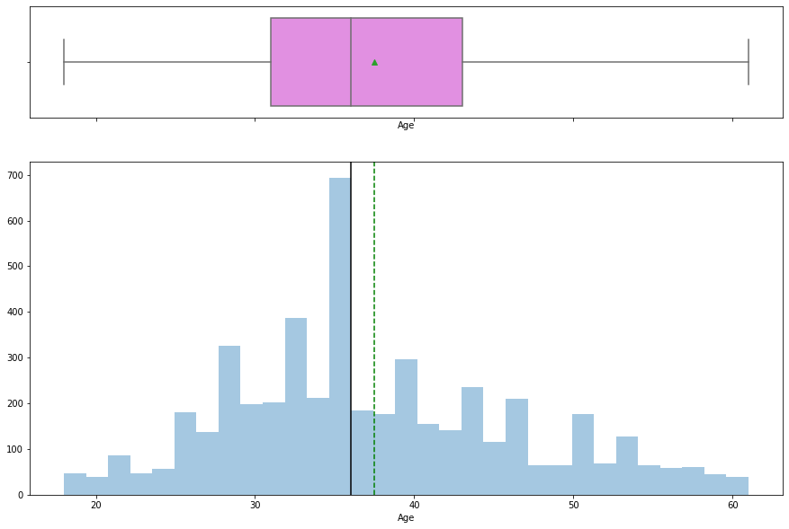

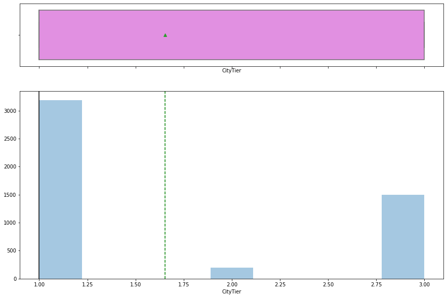

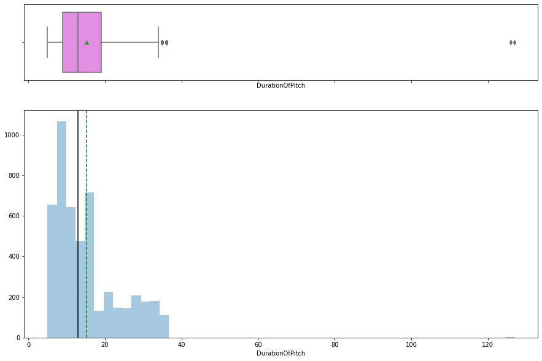

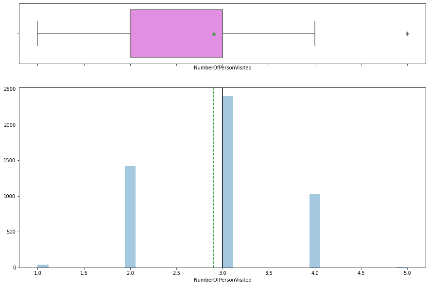

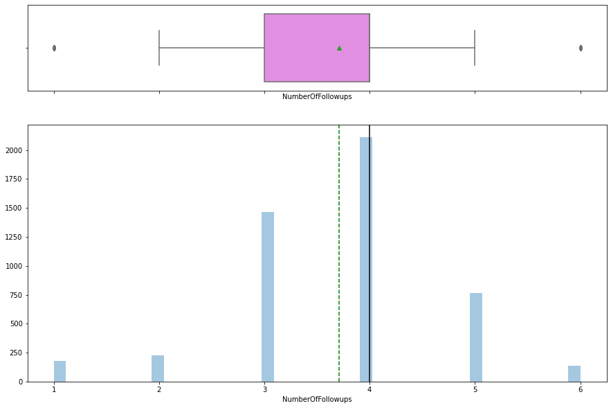

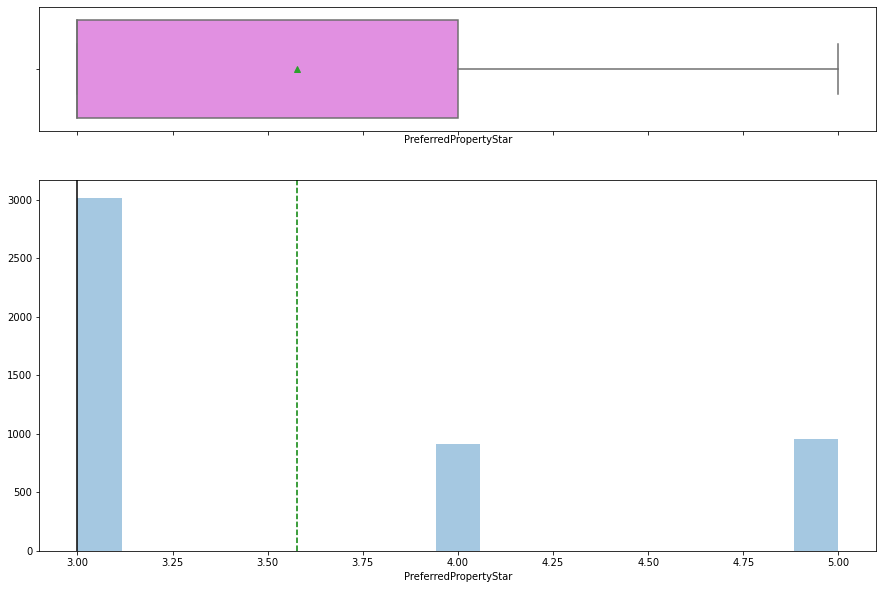

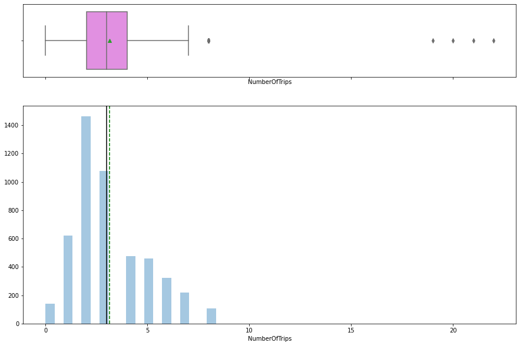

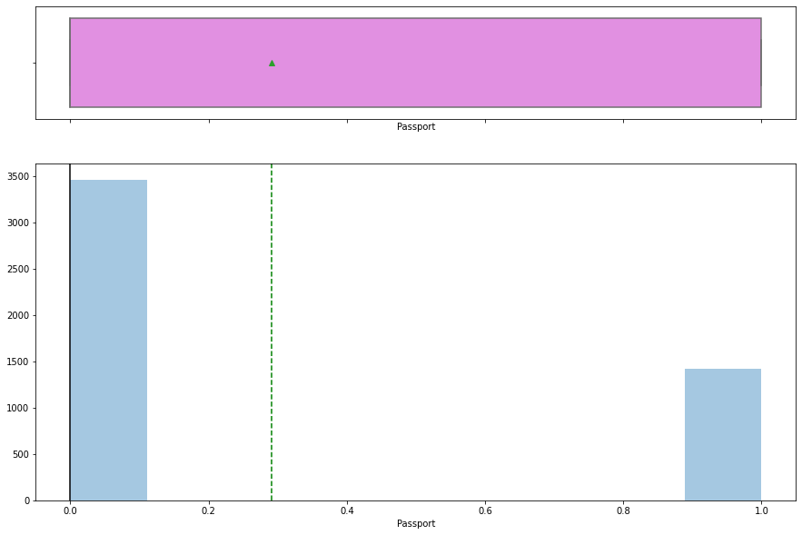

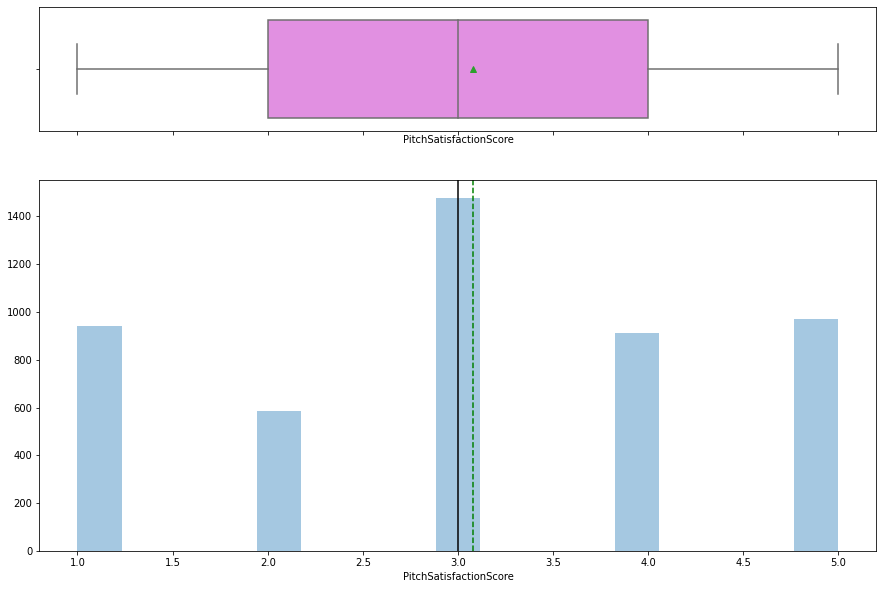

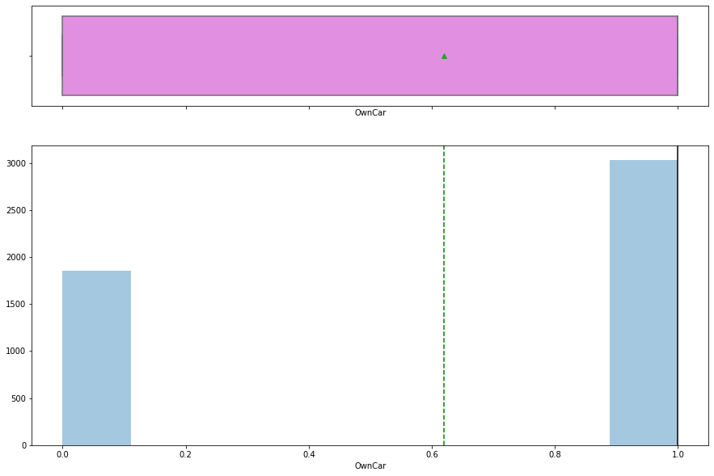

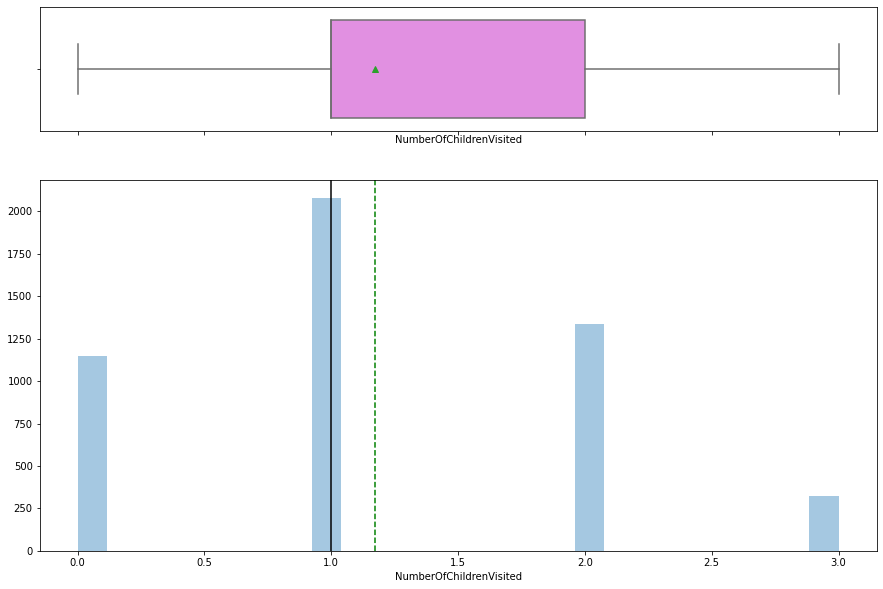

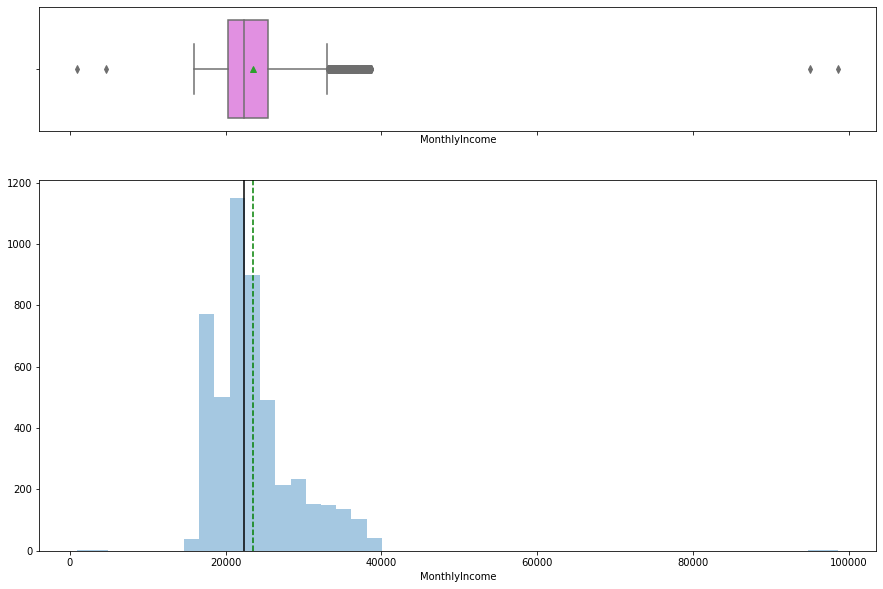

[17 more figures not shown]

```python
for feature in ['Age', 'CityTier', 'DurationOfPitch',
       'NumberOfPersonVisited', 'NumberOfFollowups', 'PreferredPropertyStar',
       'NumberOfTrips', 'Passport', 'PitchSatisfactionScore', 'OwnCar',
       'NumberOfChildrenVisited', 'MonthlyIncome', 'TypeofContact_Company Invited',
       'TypeofContact_Self Enquiry', 'Occupation_Free Lancer',
       'Occupation_Large Business', 'Occupation_Salaried',
       'Occupation_Small Business', 'Gender_Female', 'Gender_Male',
       'ProductPitched_Basic', 'ProductPitched_Deluxe', 'ProductPitched_King',
       'ProductPitched_Standard', 'ProductPitched_Super Deluxe',
       'MaritalStatus_Divorced', 'MaritalStatus_Married',
       'MaritalStatus_Single', 'MaritalStatus_Unmarried']:
    histogram_boxplot(tourDF[feature])
```

**Insights**

1. Tier - 1 city has 3000 entries
2. customers with 1 kids preferred to take tour.
3. customers with income around 20000 - takes more tour.

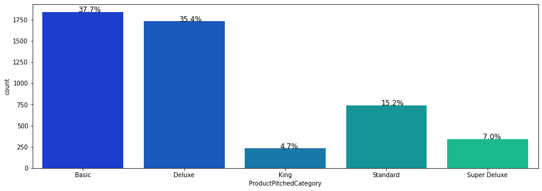

```python
plt.figure(figsize=(15,5))
ax = sns.countplot(tourDF["ProductPitchedCategory"],palette='winter')
perc_on_bar(ax,tourDF["ProductPitchedCategory"])
```

**Insights**

1. Basic is highly pitched category 37.7%
2. Deluxe has 35%
3. Followed by standard, super deluxe, king

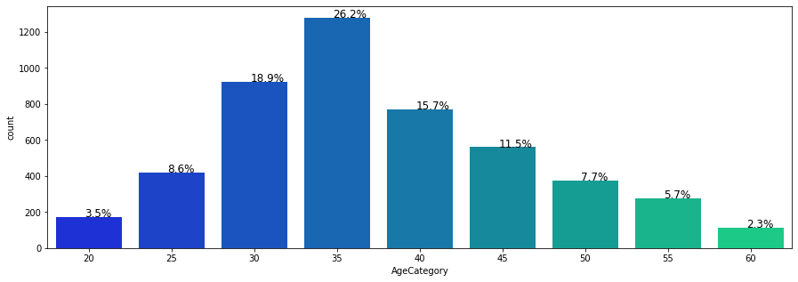

```python
plt.figure(figsize=(15,5))
ax = sns.countplot(tourDF["AgeCategory"],palette='winter')
perc_on_bar(ax,tourDF["AgeCategory"])
```

**Insights**

1. Age 35 is targeted in the data
2. Data looks to be symmetric.
3. Earlier we noticed number of customer early age 20 to 30 takess more tour.

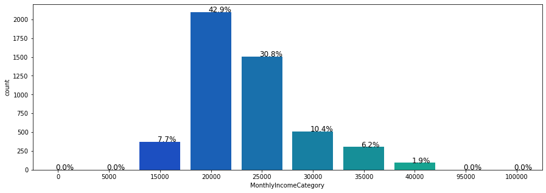

```python
plt.figure(figsize=(15,5))
ax = sns.countplot(tourDF["MonthlyIncomeCategory"],palette='winter')
perc_on_bar(ax,tourDF["MonthlyIncomeCategory"])
```

**Insights**

1. Monthly income of 20000 is major group.

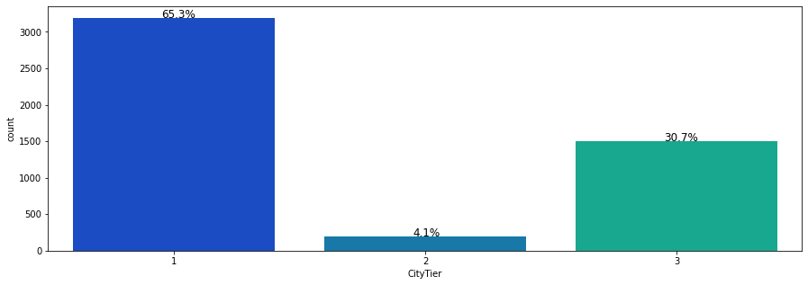

```python
plt.figure(figsize=(15,5))
ax = sns.countplot(tourDF["CityTier"],palette='winter')
perc_on_bar(ax,tourDF["CityTier"])
```

**Inisght**

- Tier 1 city have been contacted more for the tour.
- Surprisingly Tier-2 forms least percentage 4.1%

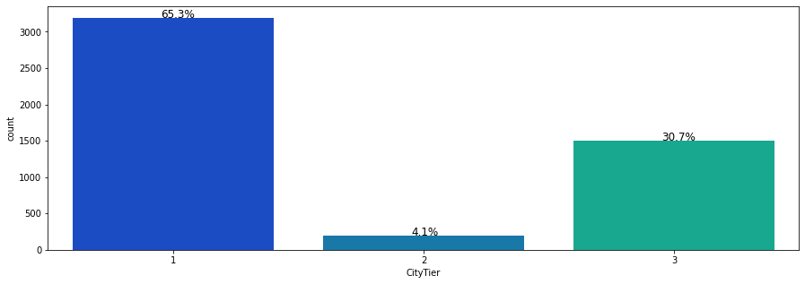

```python
plt.figure(figsize=(15,5))
ax = sns.countplot(tourDF["CityTier"],palette='winter')
perc_on_bar(ax,tourDF["CityTier"])
```

```python
tourDF.columns
```

```
Index(['CustomerID', 'ProdTaken', 'Age', 'CityTier', 'DurationOfPitch',
       'NumberOfPersonVisited', 'NumberOfFollowups', 'PreferredPropertyStar',
       'NumberOfTrips', 'Passport', 'PitchSatisfactionScore', 'OwnCar',
       'NumberOfChildrenVisited', 'MonthlyIncome', 'ProductPitchedCategory',
       'DesignationCategory', 'TypeofContact_Company Invited',
       'TypeofContact_Self Enquiry', 'Occupation_Free Lancer',
       'Occupation_Large Business', 'Occupation_Salaried',
       'Occupation_Small Business', 'Gender_Female', 'Gender_Male',
       'ProductPitched_Basic', 'ProductPitched_Deluxe', 'ProductPitched_King',
       'ProductPitched_Standard', 'ProductPitched_Super Deluxe',
       'MaritalStatus_Divorced', 'MaritalStatus_Married',
       'MaritalStatus_Single', 'MaritalStatus_Unmarried', 'Designation_AVP',
       'Designation_Executive', 'Designation_Manager',
       'Designation_Senior Manager', 'Designation_VP',
       'DurationOfPitchRounded', 'MonthlyIncomeCategory', 'AgeCategory'],
      dtype='object')
```

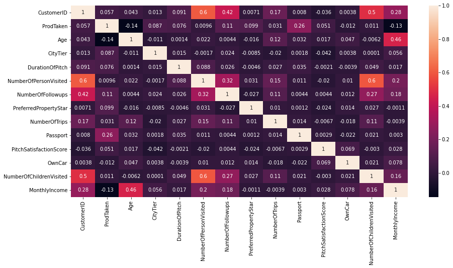

```python
plt.figure(figsize=(15,7))
sns.heatmap(tourDF_beforeEncoding.corr(),annot=True)
plt.show()
```

## **Insights**

1. ProdTaken - positively correlated with passport (0.26)
2. Suprise - montly income is negatively correlated.
3. when number of followup increases the prodtaken looks increase slightly.
4. Having own car is negatively correlated slightly with product taken

**BI Variate Analysis**

```python
tourDF.columns
```

```
Index(['CustomerID', 'ProdTaken', 'Age', 'CityTier', 'DurationOfPitch',
       'NumberOfPersonVisited', 'NumberOfFollowups', 'PreferredPropertyStar',
       'NumberOfTrips', 'Passport', 'PitchSatisfactionScore', 'OwnCar',
       'NumberOfChildrenVisited', 'MonthlyIncome', 'ProductPitchedCategory',
       'DesignationCategory', 'TypeofContact_Company Invited',
       'TypeofContact_Self Enquiry', 'Occupation_Free Lancer',
       'Occupation_Large Business', 'Occupation_Salaried',
       'Occupation_Small Business', 'Gender_Female', 'Gender_Male',
       'ProductPitched_Basic', 'ProductPitched_Deluxe', 'ProductPitched_King',
       'ProductPitched_Standard', 'ProductPitched_Super Deluxe',
       'MaritalStatus_Divorced', 'MaritalStatus_Married',
       'MaritalStatus_Single', 'MaritalStatus_Unmarried', 'Designation_AVP',
       'Designation_Executive', 'Designation_Manager',
       'Designation_Senior Manager', 'Designation_VP',
       'DurationOfPitchRounded', 'MonthlyIncomeCategory', 'AgeCategory'],
      dtype='object')
```

**Product Pitched Vs Montly Income with hue prod Taken**

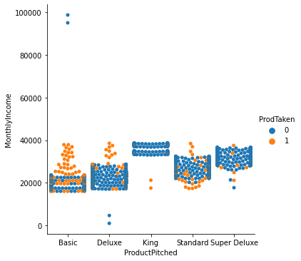

```python
# sns.pairplot(tourDF[['Age','NumberOfChildrenVisited']])
sns.catplot(x="ProductPitched", y="MonthlyIncome", hue="ProdTaken", kind="swarm", data=tourDF_beforeEncoding)
```

# **Insights**

1. Basic product pitch succeeded in 20000 to 40000 - evenly spread.
2. King product pitch is least successful.
3. Standard and Deluxe looks next popular among 20000 to 40000 range

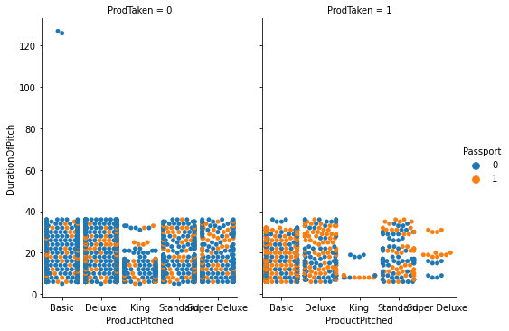

```python
# sns.catplot(x="ProductPitched", y="DurationOfPitch", hue="ProdTaken", kind="swarm", data=tourDF_beforeEncoding)

sns.catplot(x="ProductPitched", y="DurationOfPitch", hue="Passport",
            col="ProdTaken", aspect=.7,
            kind="swarm", data=tourDF_beforeEncoding)
```

**Insights**

1. With Passport customers intersted in taking Tour.
2. Basic, Deleuxe, super Deluxe has tour taken with the passport.

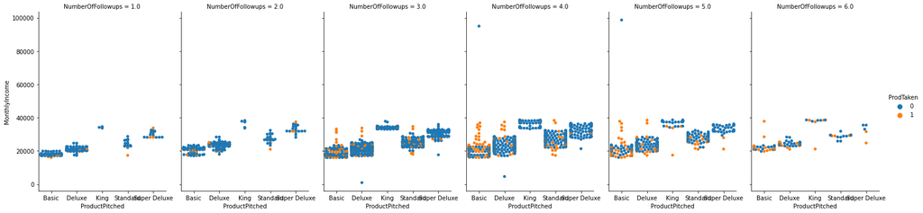

```python
# NumberOfFollowups
sns.catplot(x="ProductPitched", y="MonthlyIncome", hue="ProdTaken",
            col="NumberOfFollowups", aspect=.7,
            kind="swarm", data=tourDF_beforeEncoding)
```

# **Insights**

1. When number of follow up increases customer taking the product increases.
2. When followup is 4 to 5, customer taking product increases.

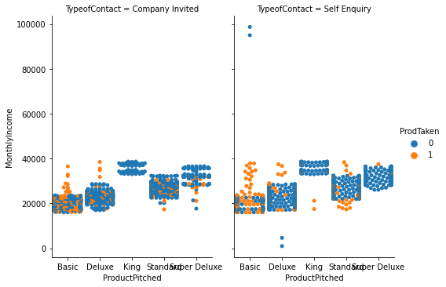

```python
# NumberOfFollowups
sns.catplot(x="ProductPitched", y="MonthlyIncome", hue="ProdTaken",
            col="TypeofContact", aspect=.7,
            kind="swarm", data=tourDF_beforeEncoding)
```

```python
tourDF.info()
```

```
<class 'pandas.core.frame.DataFrame'>
RangeIndex: 4888 entries, 0 to 4887
Data columns (total 41 columns):
 #   Column                         Non-Null Count  Dtype
---  ------                         --------------  -----
 0   CustomerID                     4888 non-null   int64
 1   ProdTaken                      4888 non-null   int64
 2   Age                            4888 non-null   float64
 3   CityTier                       4888 non-null   int64
 4   DurationOfPitch                4888 non-null   float64
 5   NumberOfPersonVisited          4888 non-null   int64
 6   NumberOfFollowups              4888 non-null   float64
 7   PreferredPropertyStar          4888 non-null   float64
 8   NumberOfTrips                  4888 non-null   float64
 9   Passport                       4888 non-null   int64
```

[output cut: 33 more lines]

# *Removing unneeded columns from data frame*

```python
tourDF.drop(columns=['CustomerID','AgeCategory','MonthlyIncomeCategory','DurationOfPitchRounded','DesignationCategory','ProductPitchedCategory'],inplace=True)
tourDF.info()
```

```
<class 'pandas.core.frame.DataFrame'>
RangeIndex: 4888 entries, 0 to 4887
Data columns (total 35 columns):
 #   Column                         Non-Null Count  Dtype
---  ------                         --------------  -----
 0   ProdTaken                      4888 non-null   int64
 1   Age                            4888 non-null   float64
 2   CityTier                       4888 non-null   int64
 3   DurationOfPitch                4888 non-null   float64
 4   NumberOfPersonVisited          4888 non-null   int64
 5   NumberOfFollowups              4888 non-null   float64
 6   PreferredPropertyStar          4888 non-null   float64
 7   NumberOfTrips                  4888 non-null   float64
 8   Passport                       4888 non-null   int64
 9   PitchSatisfactionScore         4888 non-null   int64
```

[output cut: 27 more lines]

```python
tourDF.columns = tourDF.columns.str.replace(' ','_')
```

Creating dataframe to target for wellness campaign

```python
wellNessTargetedDF = tourDF[tourDF['Age'] > 35]
```

```python
wellNessTargetedDF.columns
```

```
Index(['ProdTaken', 'Age', 'CityTier', 'DurationOfPitch',
       'NumberOfPersonVisited', 'NumberOfFollowups', 'PreferredPropertyStar',
       'NumberOfTrips', 'Passport', 'PitchSatisfactionScore', 'OwnCar',
       'NumberOfChildrenVisited', 'MonthlyIncome',
       'TypeofContact_Company_Invited', 'TypeofContact_Self_Enquiry',
       'Occupation_Free_Lancer', 'Occupation_Large_Business',
       'Occupation_Salaried', 'Occupation_Small_Business', 'Gender_Female',
       'Gender_Male', 'ProductPitched_Basic', 'ProductPitched_Deluxe',
       'ProductPitched_King', 'ProductPitched_Standard',
       'ProductPitched_Super_Deluxe', 'MaritalStatus_Divorced',
       'MaritalStatus_Married', 'MaritalStatus_Single',
       'MaritalStatus_Unmarried', 'Designation_AVP', 'Designation_Executive',
       'Designation_Manager', 'Designation_Senior_Manager', 'Designation_VP'],
      dtype='object')
```

## **Split the data into train and test sets**

```python
X = tourDF.drop("ProdTaken" , axis=1)
y = tourDF.pop("ProdTaken")
```

```python
X_train, X_test, y_train, y_test = train_test_split(X, y, test_size=.30, random_state=1,stratify=y)
```

```python
# Function to create confusion matrix
def make_confusion_matrix(model,y_actual,labels=[1, 0]):
    '''
    model : classifier to predict values of X
    y_actual : ground truth

    '''
    y_predict = model.predict(X_test)
    cm=metrics.confusion_matrix( y_actual, y_predict, labels=[0, 1])
    df_cm = pd.DataFrame(cm, index = [i for i in ["Actual - No","Actual - Yes"]],
                  columns = [i for i in ['Predicted - No','Predicted - Yes']])
    group_counts = ["{0:0.0f}".format(value) for value in
                cm.flatten()]
    group_percentages = ["{0:.2%}".format(value) for value in
                         cm.flatten()/np.sum(cm)]
    labels = [f"{v1}\n{v2}" for v1, v2 in
              zip(group_counts,group_percentages)]
    labels = np.asarray(labels).reshape(2,2)
    plt.figure(figsize = (10,7))
    sns.heatmap(df_cm, annot=labels,fmt='')
    plt.ylabel('True label')
    plt.xlabel('Predicted label')
```

```python
##  Function to calculate different metric scores of the model - Accuracy, Recall and Precision
def get_metrics_score(model,flag=True):
    '''
    model : classifier to predict values of X

    '''
    # defining an empty list to store train and test results
    score_list=[]

    pred_train = model.predict(X_train)
    pred_test = model.predict(X_test)

    train_acc = model.score(X_train,y_train)
    test_acc = model.score(X_test,y_test)

    train_recall = metrics.recall_score(y_train,pred_train)
    test_recall = metrics.recall_score(y_test,pred_test)

    train_precision = metrics.precision_score(y_train,pred_train)
    test_precision = metrics.precision_score(y_test,pred_test)

    score_list.extend((train_acc,test_acc,train_recall,test_recall,train_precision,test_precision))

    # If the flag is set to True then only the following print statements will be dispayed. The default value is set to True.
    if flag == True:
        print("Accuracy on training set : ",model.score(X_train,y_train))
        print("Accuracy on test set : ",model.score(X_test,y_test))
        print("Recall on training set : ",metrics.recall_score(y_train,pred_train))
        print("Recall on test set : ",metrics.recall_score(y_test,pred_test))
        print("Precision on training set : ",metrics.precision_score(y_train,pred_train))
        print("Precision on test set : ",metrics.precision_score(y_test,pred_test))

    return score_list # returning the list with train and test scores
```

## **Model building - Bagging**

```python
#base_estimator for bagging classifier is a decision tree by default
bagging_estimator=BaggingClassifier(random_state=1)
bagging_estimator.fit(X_train,y_train)
```

```
BaggingClassifier(base_estimator=None, bootstrap=True, bootstrap_features=False,
                  max_features=1.0, max_samples=1.0, n_estimators=10,
                  n_jobs=None, oob_score=False, random_state=1, verbose=0,
                  warm_start=False)
```

```python
# Using above defined function to get accuracy, recall and precision on train and test set
bagging_estimator_score=get_metrics_score(bagging_estimator)
```

```
Accuracy on training set :  0.9944460684010523
Accuracy on test set :  0.9045671438309475
Recall on training set :  0.9704968944099379
Recall on test set :  0.572463768115942
Precision on training set :  1.0
Precision on test set :  0.8777777777777778
```

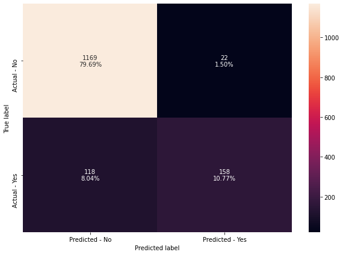

```python
make_confusion_matrix(bagging_estimator,y_test)
```

**Insights of Bagging with Decision Tree**

1. Model did over fitting on training data.
2. Testing data for recall is around : 57%
3. Precision for testing data is around: 87%

```python
#Train the random forest classifier
rf_estimator=RandomForestClassifier(random_state=1)
rf_estimator.fit(X_train,y_train)
```

```
RandomForestClassifier(bootstrap=True, ccp_alpha=0.0, class_weight=None,
                       criterion='gini', max_depth=None, max_features='auto',
                       max_leaf_nodes=None, max_samples=None,
                       min_impurity_decrease=0.0, min_impurity_split=None,
                       min_samples_leaf=1, min_samples_split=2,
                       min_weight_fraction_leaf=0.0, n_estimators=100,
                       n_jobs=None, oob_score=False, random_state=1, verbose=0,
                       warm_start=False)
```

```python
rf_estimator_score=get_metrics_score(rf_estimator)
```

```
Accuracy on training set :  1.0
Accuracy on test set :  0.9066121336059987
Recall on training set :  1.0
Recall on test set :  0.5507246376811594
Precision on training set :  1.0
Precision on test set :  0.9212121212121213
```

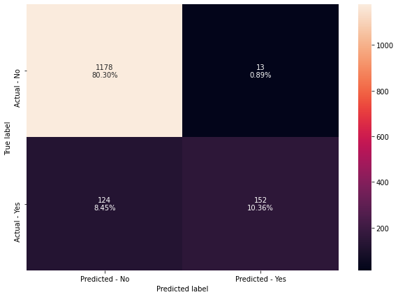

```python
make_confusion_matrix(rf_estimator,y_test)
```

**Insights of Random forest Classifier**

1. The model is overfitting the data, as train accuracy ,precision and recall are much higher than the test accuracy and test recall.
2. Testing data Recall (55%) looks far from training data recall.
3. Precision for Testing data is around 91%

```python
# Choose the type of classifier.
bagging_estimator_tuned = BaggingClassifier(random_state=1)

# Grid of parameters to choose from
## add from article
parameters = {'max_samples': [0.7,0.8,0.9,1],
              'max_features': [0.7,0.8,0.9,1],
              'n_estimators' : [10,20,30,40,50,60,70,80,90]
             }

# Type of scoring used to compare parameter combinations
acc_scorer = metrics.make_scorer(metrics.recall_score)

# Run the grid search



if no_grid_search:
  bagging_estimator_tuned = BaggingClassifier(base_estimator=None, bootstrap=True, bootstrap_features=False,
                  max_features=0.9, max_samples=0.9, n_estimators=90,
                  n_jobs=None, oob_score=False, random_state=1, verbose=0,
                  warm_start=False)
else:
  grid_obj = GridSearchCV(bagging_estimator_tuned, parameters, scoring=acc_scorer,cv=5)
  grid_obj = grid_obj.fit(X_train, y_train)
  # Set the clf to the best combination of parameters
  bagging_estimator_tuned = grid_obj.best_estimator_



# Fit the best algorithm to the data.
bagging_estimator_tuned.fit(X_train, y_train)
```

```
BaggingClassifier(base_estimator=None, bootstrap=True, bootstrap_features=False,
                  max_features=0.9, max_samples=0.9, n_estimators=90,
                  n_jobs=None, oob_score=False, random_state=1, verbose=0,
                  warm_start=False)
```

```python
#Using above defined function to get accuracy, recall and precision on train and test set
bagging_estimator_tuned_score=get_metrics_score(bagging_estimator_tuned)
```

```
Accuracy on training set :  0.9994153756211634
Accuracy on test set :  0.9216087252897068
Recall on training set :  0.9968944099378882
Recall on test set :  0.6340579710144928
Precision on training set :  1.0
Precision on test set :  0.9259259259259259
```

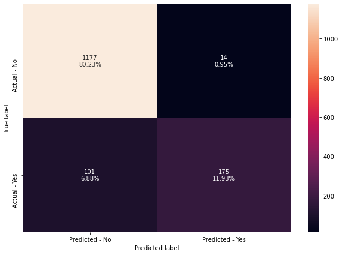

```python
make_confusion_matrix(bagging_estimator_tuned,y_test)
```

## **Insights of model buildingbagging**

**Changing Bagging Base Estimator to Logistics Regression**

```python
bagging_lr=BaggingClassifier(base_estimator=LogisticRegression(random_state=1),random_state=1)
bagging_lr.fit(X_train,y_train)
```

```
BaggingClassifier(base_estimator=LogisticRegression(C=1.0, class_weight=None,
                                                    dual=False,
                                                    fit_intercept=True,
                                                    intercept_scaling=1,
                                                    l1_ratio=None, max_iter=100,
                                                    multi_class='auto',
                                                    n_jobs=None, penalty='l2',
                                                    random_state=1,
                                                    solver='lbfgs', tol=0.0001,
                                                    verbose=0,
                                                    warm_start=False),
                  bootstrap=True, bootstrap_features=False, max_features=1.0,
                  max_samples=1.0, n_estimators=10, n_jobs=None,
                  oob_score=False, random_state=1, verbose=0, warm_start=False)
```

```python
#Using above defined function to get accuracy, recall and precision on train and test set
bagging_lr_score=get_metrics_score(bagging_lr)
```

```
Accuracy on training set :  0.8363051739257527
Accuracy on test set :  0.8261758691206544
Recall on training set :  0.18944099378881987
Recall on test set :  0.15217391304347827
Precision on training set :  0.7625
Precision on test set :  0.6666666666666666
```

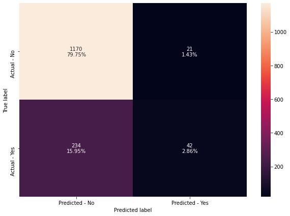

```python
make_confusion_matrix(bagging_lr,y_test)
```

**Insights for Logisitic Regression based bagging**

Though prediction as a whole has been degraded, it acted equal for both test and train data.

But for us, We cannot consider this model.

## **model Performance Improvement**

# **Rand Forest Classifier - Hyper Tunning**

```python
# Choose the type of classifier.
rf_estimator_tuned = RandomForestClassifier(random_state=1)

# Grid of parameters to choose from
## add from article
parameters = {"n_estimators": [150,200,250],
    "min_samples_leaf": np.arange(5, 10),
    "max_features": np.arange(0.2, 0.7, 0.1),
    "max_samples": np.arange(0.3, 0.7, 0.1),
             }

# Type of scoring used to compare parameter combinations
acc_scorer = metrics.make_scorer(metrics.recall_score)


if no_grid_search:
  rf_estimator_tuned =  RandomForestClassifier(bootstrap=True, ccp_alpha=0.0, class_weight=None,
                        criterion='gini', max_depth=None,
                        max_features=0.6000000000000001, max_leaf_nodes=None,
                        max_samples=0.6000000000000001,
                        min_impurity_decrease=0.0, min_impurity_split=None,
                        min_samples_leaf=5, min_samples_split=2,
                        min_weight_fraction_leaf=0.0, n_estimators=150,
                        n_jobs=None, oob_score=False, random_state=1, verbose=0,
                        warm_start=False)
else:
  # # Run the grid search
  grid_obj = GridSearchCV(rf_estimator_tuned, parameters, scoring=acc_scorer,cv=5)
  grid_obj = grid_obj.fit(X_train, y_train)
  # Set the clf to the best combination of parameters
  rf_estimator_tuned = grid_obj.best_estimator_



# Fit the best algorithm to the data.
rf_estimator_tuned.fit(X_train, y_train)
```

```
RandomForestClassifier(bootstrap=True, ccp_alpha=0.0, class_weight=None,
                       criterion='gini', max_depth=None,
                       max_features=0.6000000000000001, max_leaf_nodes=None,
                       max_samples=0.6000000000000001,
                       min_impurity_decrease=0.0, min_impurity_split=None,
                       min_samples_leaf=5, min_samples_split=2,
                       min_weight_fraction_leaf=0.0, n_estimators=150,
                       n_jobs=None, oob_score=False, random_state=1, verbose=0,
                       warm_start=False)
```

```python
#Using above defined function to get accuracy, recall and precision on train and test set
rf_estimator_tuned_score=get_metrics_score(rf_estimator_tuned)
```

```
Accuracy on training set :  0.9085062847120725
Accuracy on test set :  0.874573960463531
Recall on training set :  0.5388198757763976
Recall on test set :  0.4057971014492754
Precision on training set :  0.9559228650137741
Precision on test set :  0.8484848484848485
```

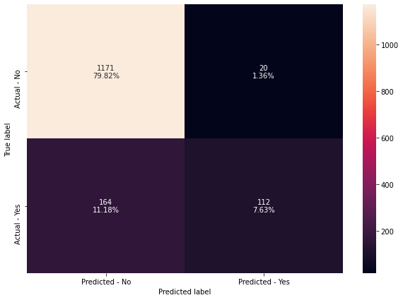

```python
make_confusion_matrix(rf_estimator_tuned,y_test)
```

**Insight for Random Forest Classifier**

1. False Negative is greater then true positive, which impacts Recall
2. Model works good on training data than test data

**Random Forest with class Weighted**

```python
# Choose the type of classifier.
rf_estimator_weighted = RandomForestClassifier(random_state=1)

# Grid of parameters to choose from
## add from article
parameters = {
    "class_weight": [{0: 0.3, 1: 0.7}],
    "n_estimators": [100,150,200,250],
    "min_samples_leaf": np.arange(5, 10),
    "max_features": np.arange(0.2, 0.7, 0.1),
    "max_samples": np.arange(0.3, 0.7, 0.1),
}

# Type of scoring used to compare parameter combinations
acc_scorer = metrics.make_scorer(metrics.recall_score)


if no_grid_search:
  rf_estimator_weighted = RandomForestClassifier(bootstrap=True, ccp_alpha=0.0,
                        class_weight={0: 0.3, 1: 0.7}, criterion='gini',
                        max_depth=None, max_features=0.5000000000000001,
                        max_leaf_nodes=None, max_samples=0.6000000000000001,
                        min_impurity_decrease=0.0, min_impurity_split=None,
                        min_samples_leaf=7, min_samples_split=2,
                        min_weight_fraction_leaf=0.0, n_estimators=250,
                        n_jobs=None, oob_score=False, random_state=1, verbose=0,
                        warm_start=False)
else:
  # # Run the grid search
  grid_obj = GridSearchCV(rf_estimator_weighted, parameters, scoring=acc_scorer,cv=5)
  grid_obj = grid_obj.fit(X_train, y_train)

  # Set the clf to the best combination of parameters
  rf_estimator_weighted = grid_obj.best_estimator_

# Fit the best algorithm to the data.
rf_estimator_weighted.fit(X_train, y_train)
```

```
RandomForestClassifier(bootstrap=True, ccp_alpha=0.0,
                       class_weight={0: 0.3, 1: 0.7}, criterion='gini',
                       max_depth=None, max_features=0.5000000000000001,
                       max_leaf_nodes=None, max_samples=0.6000000000000001,
                       min_impurity_decrease=0.0, min_impurity_split=None,
                       min_samples_leaf=7, min_samples_split=2,
                       min_weight_fraction_leaf=0.0, n_estimators=250,
                       n_jobs=None, oob_score=False, random_state=1, verbose=0,
                       warm_start=False)
```

```python
#Using above defined function to get accuracy, recall and precision on train and test set
rf_estimator_weighted_score=get_metrics_score(rf_estimator_weighted)
```

```
Accuracy on training set :  0.9123063431745104
Accuracy on test set :  0.8779822767552828
Recall on training set :  0.6987577639751553
Recall on test set :  0.5507246376811594
Precision on training set :  0.8093525179856115
Precision on test set :  0.7342995169082126
```

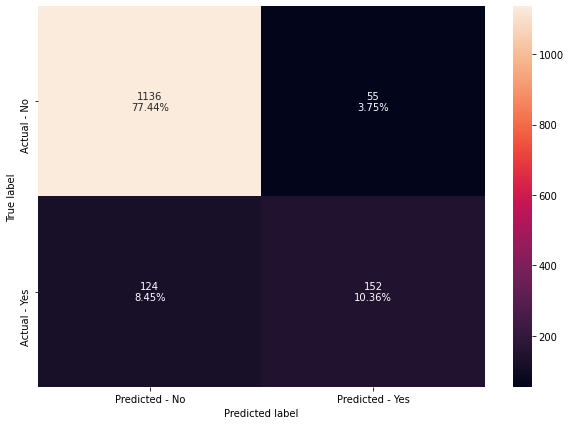

```python
make_confusion_matrix(rf_estimator_weighted,y_test)
```

# **Insights**

1. Model has improved recall with class weight.
2. Model moves little closer to test and train data.

## **Insights of model Performance Improvement**

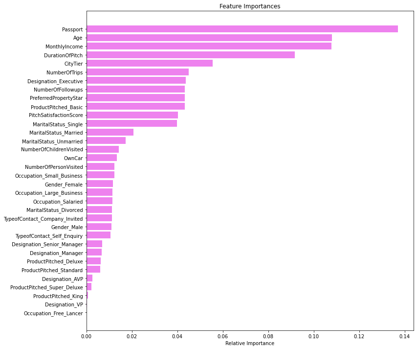

```python
importances = rf_estimator_weighted.feature_importances_
indices = np.argsort(importances)
feature_names = list(X.columns)

plt.figure(figsize=(12,12))
plt.title('Feature Importances')
plt.barh(range(len(indices)), importances[indices], color='violet', align='center')
plt.yticks(range(len(indices)), [feature_names[i] for i in indices])
plt.xlabel('Relative Importance')
plt.show()
```

**Insights of Feature importance**

1. customers with passport has taken the product pitched which is evident even in the plot earlier.
2. Age, Monthly Income - has equal important factor for a person to take the tour.
3. Duration of Pitch , city tier, Number of trips - plays next few important factors on this model

## **Model building - Boosting**

```python
abc = AdaBoostClassifier(random_state=1)
abc.fit(X_train,y_train)
```

```
AdaBoostClassifier(algorithm='SAMME.R', base_estimator=None, learning_rate=1.0,
                   n_estimators=50, random_state=1)
```

```python
#Using above defined function to get accuracy, recall and precision on train and test set
abc_score=get_metrics_score(abc)
```

```
Accuracy on training set :  0.8447822274188833
Accuracy on test set :  0.8432174505794138
Recall on training set :  0.31211180124223603
Recall on test set :  0.31521739130434784
Precision on training set :  0.6955017301038062
Precision on test set :  0.6796875
```

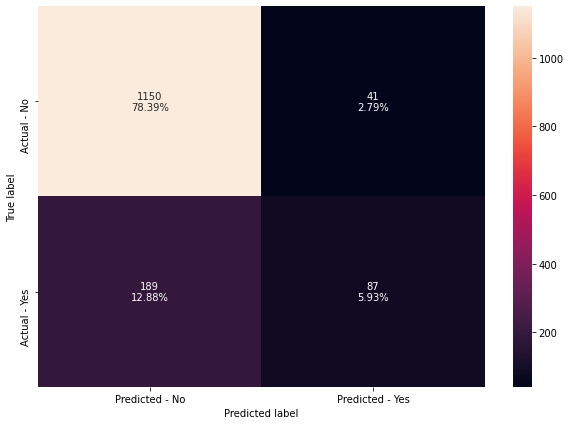

```python
make_confusion_matrix(abc,y_test)
```

# **Insights**

1. True positive is less than than false negative.
2. Recall stands at 31%
3. Model performs equal for both Training and Testing data

## **Model : Boosting - Gradient Boosting**

```python
gbc = GradientBoostingClassifier(random_state=1)
gbc.fit(X_train,y_train)
```

```
GradientBoostingClassifier(ccp_alpha=0.0, criterion='friedman_mse', init=None,
                           learning_rate=0.1, loss='deviance', max_depth=3,
                           max_features=None, max_leaf_nodes=None,
                           min_impurity_decrease=0.0, min_impurity_split=None,
                           min_samples_leaf=1, min_samples_split=2,
                           min_weight_fraction_leaf=0.0, n_estimators=100,
                           n_iter_no_change=None, presort='deprecated',
                           random_state=1, subsample=1.0, tol=0.0001,
                           validation_fraction=0.1, verbose=0,
                           warm_start=False)
```

```python
#Using above defined function to get accuracy, recall and precision on train and test set
gbc_score=get_metrics_score(gbc)
```

```
Accuracy on training set :  0.8871674948845367
Accuracy on test set :  0.869120654396728
Recall on training set :  0.45652173913043476
Recall on test set :  0.40217391304347827
Precision on training set :  0.8909090909090909
Precision on test set :  0.8043478260869565
```

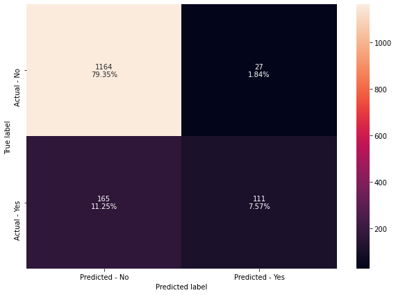

```python
make_confusion_matrix(gbc,y_test)
```

**Insights for Gradient Boosting**

1. Model performance over all increased when comparing to Ada boosting.
2. Recall has been improved to 40%

## **XGB Classifier**

```python
xgb = XGBClassifier(random_state=1)
xgb.fit(X_train,y_train)
```

```
XGBClassifier(base_score=0.5, booster='gbtree', colsample_bylevel=1,
              colsample_bynode=1, colsample_bytree=1, gamma=0,
              learning_rate=0.1, max_delta_step=0, max_depth=3,
              min_child_weight=1, missing=None, n_estimators=100, n_jobs=1,
              nthread=None, objective='binary:logistic', random_state=1,
              reg_alpha=0, reg_lambda=1, scale_pos_weight=1, seed=None,
              silent=None, subsample=1, verbosity=1)
```

```python
#Using above defined function to get accuracy, recall and precision on train and test set
xgb_score=get_metrics_score(xgb)
```

```
Accuracy on training set :  0.8792750657702426
Accuracy on test set :  0.8650306748466258
Recall on training set :  0.42391304347826086
Recall on test set :  0.37318840579710144
Precision on training set :  0.8666666666666667
Precision on test set :  0.8046875
```

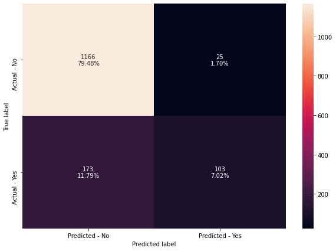

```python
make_confusion_matrix(xgb,y_test)
```

## **Insight Model building - Boosting**

1. with random state, the ada boosing, gradient boosting and XG boosting - performance looks normal and less than bagging